# Comparison of omics data type properties

Sonia Tarazona, Ángeles Arzalluz-Luque, Ana Conesa

13/05/2021

This [R Markdown](http://rmarkdown.rstudio.com) Notebook contains the necessary code to generate Figure 3 in **Tarazona et al. (2021): “Undisclosed, unmet and neglected challenges in multi-omics studies”, *Nature Computational Sciences***. In this figure, the STATegra dataset [^1] was used as an example to compare properties of different omics data types. The STATegra dataset was generated for a transcription factor Ikaros-induced mouse B-cell differentiation time-course.

### Data preparation

First, we defined some custom color palettes for consistency in the representation of the different omics.

```r
# set omic data names
Omics <- c("RNA-seq", "scRNA-seq", "miRNA-seq", "RRBS", "ChIP-seq",
           "DNase-seq","Metabolomics", "Proteomics")

# define plot colors
mycolors = colors()[c(554,89,111,512,17,586,132,428,601,568,86,390)]
names(mycolors) = Omics
```

To generate the plots, load the necessary data from the `Figure3.rdata` file.

```r
load("Figure3.RData")
```

### Figure 3.a: signal-to-noise plot.

The plot in **Figure 3.a** includes a comparison between the signal-to-noise ratio of the different omics in the STATegra dataset.

First, calculate confidence intervals for the different omics:

```r
confi.change = t(sapply(myDmax, quantile, probs = c(0.25,0.75,0.5), na.rm = TRUE))
confi.var = t(sapply(mySEglobal, quantile, probs = c(0.25,0.75,0.5), na.rm = TRUE))
```

Then, set some custom graphical parameters:

```r
mycolors2 = mycolors[c(1:4,6:8)]
par(mar = c(5,4,1,1))
```

Finally generate the plot by running:

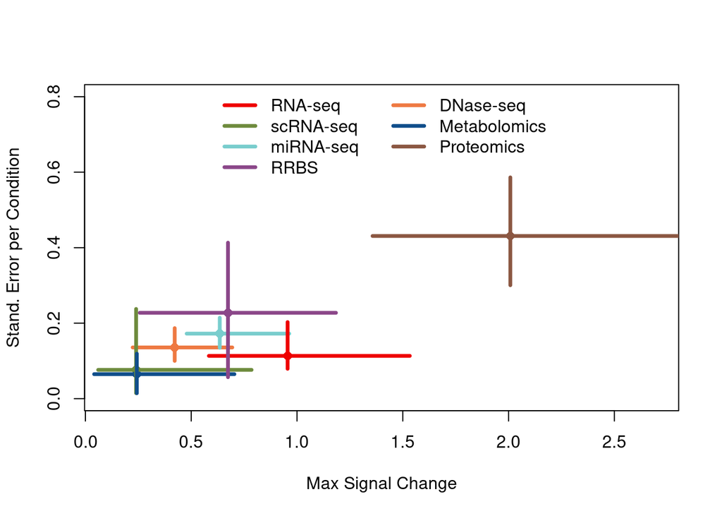

```r
plot(confi.change[,3], confi.var[,3], xlim = c(0.1,2.7), ylim = c(0,0.8),
     col = mycolors2, xlab = "Max Signal Change", ylab = "Stand. Error per Condition",
     pch = 18, main = "", cex = 1.5)
segments(x0 = confi.change[,1], y0 = confi.var[,3], x1 = confi.change[,2], y1 = confi.var[,3],
         col = mycolors2, lwd = 3.5)
segments(x0 = confi.change[,3], y0 = confi.var[,1], x1 = confi.change[,3], y1 = confi.var[,2],
         col = mycolors2, lwd = 3.5)
legend("top", names(mycolors2), ncol = 2, lwd = 3.5, col = mycolors2, bty = "n", cex = 1)
```

### Figure 3.b: number of features detected by each technology.

The plot in **Figure 3.b** compares the total number of detected features across omics data types in the STATegra dataset.

First, we need to obtain the number of features per omic from the data:

```r
Features = c(length(myDmax$RNAseq), length(myDmax$scRNAseq),
             length(myDmax$miRNAseq), length(myDmax$methylseq),
             length(STATmapping_ChipSeqGenes$Gene), length(myDmax$DNaseSeq),
             length(myDmax$metabolomics), length(myDmax$proteomics))
names(Features) = Omics
```

Then, we set graphical parameters and generate the plot:

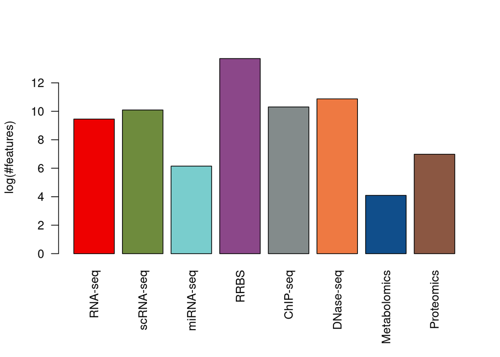

```r
par(mar = c(7.1, 4.1, 4.1, 2.1))

barplot(log(Features), names.arg = Omics,
        col = mycolors, las = 2,
        ylab = "log(#features)")
```

### Figure 3.c: differential coverage of the feature space.

This plot contains a representation of the expression levels captured by each of the omics in the STATegra dataset. In it, each line represents the density distribution of the number of features captured at each expression level for each of the methods.

The density distributions of mean feature expression across samples for each of the omics can be computed as follows:

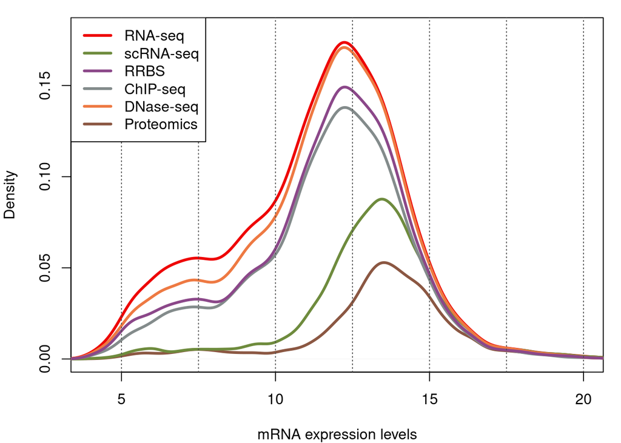

```r
# set graphical parameters
par(mar = c(4,4,1,1))

# RNA-seq
par(mar = c(4,4,1,1))
mRNAavg = rowMeans(mRNA[,grep("_Ik_", colnames(mRNA))])
plot(density(mRNAavg), col = mycolors["RNA-seq"], lwd=3, ylim=c(0,0.18), xlim=c(4,20), lty=1,
     main="",
     xlab="mRNA expression levels")

# Proteomics
gene.ENSEM<-rownames(mRNA)[mRNA[,1] %in% gene.prot[,2]]
prop_g0<-length(gene.ENSEM)/length(mRNAavg)
lines(density(mRNAavg[gene.ENSEM])$x,density(mRNAavg[gene.ENSEM])$y*(prop_g0), col = mycolors["Proteomics"], lwd=3,lty=1)

# scRNA-seq
gene.ENSEM<-rownames(mRNA)[rownames(mRNA) %in% scRNAseq_genes]
prop_g0<-length(gene.ENSEM)/length(mRNAavg)
lines(density(mRNAavg[gene.ENSEM])$x,density(mRNAavg[gene.ENSEM])$y*(prop_g0), col = mycolors["scRNA-seq"], lwd=3, lty=1)

# ChIP-seq
gene.ENSEM<-rownames(mRNA)[rownames(mRNA) %in% STATmapping_ChipSeqGenes[,"Gene"]]
prop_g0<-length(gene.ENSEM)/length(mRNAavg)
lines(density(mRNAavg[gene.ENSEM])$x,density(mRNAavg[gene.ENSEM])$y*(prop_g0), col = mycolors["ChIP-seq"], lwd=3, lty=1)

# DNase-seq
gene.ENSEM<-rownames(mRNA)[rownames(mRNA) %in% STATmapping_DNaseSeqGenes2[,"Gene"]]
prop_g0<-length(gene.ENSEM)/length(mRNAavg)
lines(density(mRNAavg[gene.ENSEM])$x,density(mRNAavg[gene.ENSEM])$y*(prop_g0), col = mycolors["DNase-seq"], lwd=3,lty=1)

# RRBS
gene.ENSEM<-rownames(mRNA)[rownames(mRNA) %in% STATmapping_MethylGenes2[,"Gene"]]
prop_g0<-length(gene.ENSEM)/length(mRNAavg)
lines(density(mRNAavg[gene.ENSEM])$x,density(mRNAavg[gene.ENSEM])$y*(prop_g0), col = mycolors["RRBS"], lwd=3, lty = 1)

# add plot features
abline(v = seq(5,20,2.5), lty = 3, col = "gray30")
legend("topleft", Omics[-c(3,7)], col = mycolors[-c(3,7)], lwd=3)#, bty = "n")
```

### Figure 3.d: statistical power comparison across omics.

This plot includes a comparison of statistical power curves across omics data types as a function of sample size. Statistical power was computed using the MultiPower[^2] software.

To reproduce this analysis, we first need to source the functions provided in the `Figure3_functions.R` script:

```r
source("Figure3_functions.R")
```

Then, execute the `powerPlot()` function as follows:

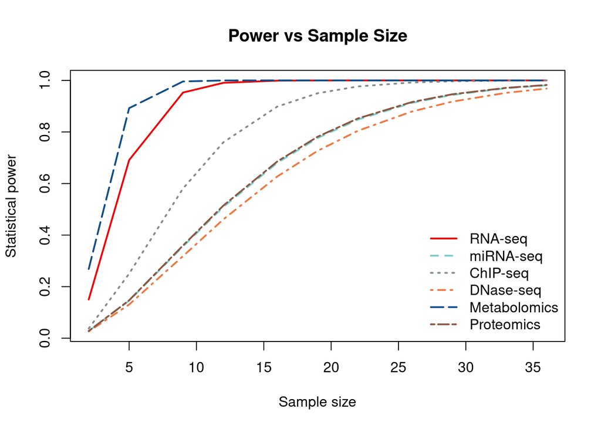

```
## $PowerVsSsampleSize
##      RNA-seq  miRNA-seq   ChIP-seq DNase-seq Metabolomics Proteomics
## 2  0.1500228 0.02785975 0.03770639 0.0262443    0.2685543 0.02791731
## 5  0.6908440 0.14562396 0.25022313 0.1304815    0.8922981 0.14703667
## 9  0.9528225 0.35566717 0.58056321 0.3183621    0.9958799 0.35954405
## 12 0.9906119 0.50942391 0.75995739 0.4610847    0.9997229 0.51452226
## 16 0.9990825 0.67989646 0.89840958 0.6272573    0.9999938 0.68541014
## 19 0.9998541 0.77649176 0.95014991 0.7268855    0.9999997 0.78160869
## 22 0.9999782 0.84823618 0.97663623 0.8048148    1.0000000 0.85262375
## 26 0.9999984 0.91271680 0.99198048 0.8793703    1.0000000 0.91597641
## 29 0.9999998 0.94372076 0.99653482 0.9177210    1.0000000 0.94619196
## 33 1.0000000 0.96950195 0.99891433 0.9518227    1.0000000 0.97111538
## 36 1.0000000 0.98108605 0.99955756 0.9682856    1.0000000 0.98221689
```

```r
# customize plot colors
mycolors2 = mycolors[-c(2,4)]

# run powerPlot()
powerPlot(parameters = statResultsEQ$parameters,
          optimalSampleSize = statResultsEQ$optimalSampleSize,
          omicCol = mycolors2)
```

[^1]: Gomez-Cabrero, D., Tarazona, S., Ferreirós-Vidal, I. et al. STATegra, a comprehensive multi-omics dataset of B-cell differentiation in mouse. Sci Data 6, 256 (2019). https://doi.org/10.1038/s41597-019-0202-7
[^2]: Tarazona, S., Balzano-Nogueira, L., Gómez-Cabrero, D. et al. Harmonization of quality metrics and power calculation in multi-omic studies. Nat Commun 11, 3092 (2020). https://doi.org/10.1038/s41467-020-16937-8